# Vignette

Silvy van Kuijk, Rachel Voyt, Allison McNamara

November 29, 2016

```r
knitr::opts_chunk$set(
    echo = TRUE,
    warning = FALSE,
    comment = "##",
    prompt = TRUE,
    tidy = TRUE,
    tidy.opts = list(width.cutoff = 75),
    fig.path = "img/"
)
```

## Key Concepts

**Geographic Coordinate Systems** refer to data that is defined by a 3-D surface and measured in latitude and longitude. The longitude is the east or west location of a point, and the latitude is the north or south location of a point. Latitude and longitude coordinates thus define locations in two or three-dimensional space. An example of a Geographic Coordinate System would be “WGS84”. You may also encounter the word “Datum” when you work with GIS. Essentially a Datum provides a frame of reference for measureing locations on the surface of the earth, so “Datum” and “Geographic Coordinate System” are sometimes used interchangeably.

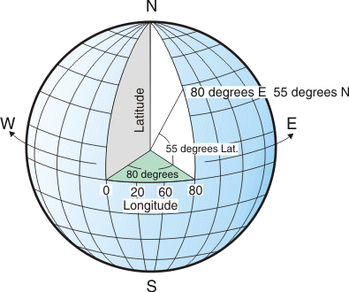

**Projected Coordinate Systems** refers to data that is defined by a flat 2-D surface and can be measured in units of meters and feet. The most important example is the **The Universal Transverse Mercator projection (UTM)**. This is a cylindrical projection of the world’s layout on a map that touches at the equator. A projection is a mathematical transformation of the globe onto some other surface, in this case, a grid. UTM is the typical projection used in GIS and spatial analyses.

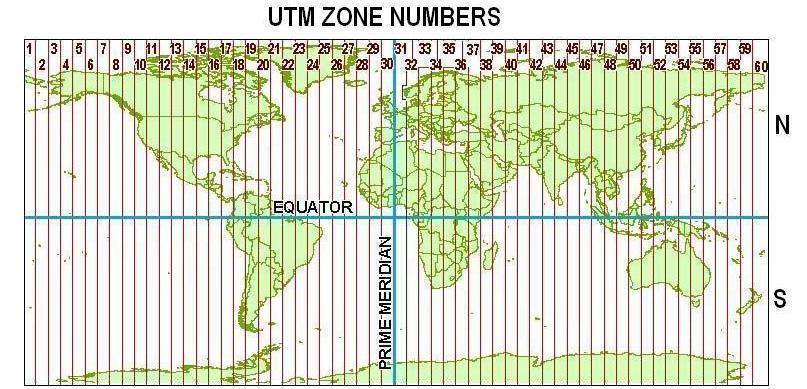

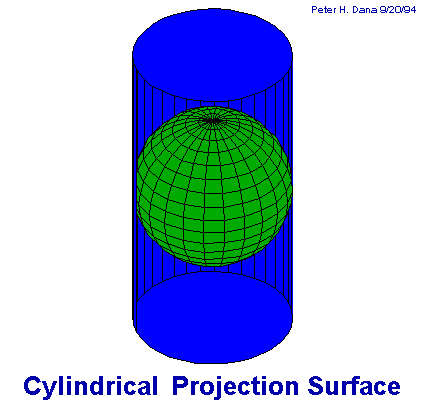

**Shapefiles** (.shp, .dbf, .shx, .prj, .sbn) store nontopological geometry and attribute information for the spatial features in a data set. The geometry for a feature is stored as a shape comprising a set of vector coordinates. Shapefiles can support point, line, and area features. One can create a shapefile on their map by downloading from an external source, digitizing, or programming. Shapefiles can be projected on a map in layers and manipulated.

**Attributes** are feature characteristics that can be plotted on a map.

**Vector data** models use discrete elements such as points, lines, and polygons to represent the geometry of real-world entities.

**Point** single point location, such as a GPS reading or a geocoded address

**Line** set of ordered points, connected by straight line segments

**Polygon** area, marked by one or more enclosing lines, possibly containing holes

**Raster data** models are the natural means to represent continuous spatial features or phenomenon. They define the world as a regular set of cells in a grid pattern that are square and evenly spaced in the x and y directions.

**Grid** collection of points or rectangular cells, organised in a regular lattice (raster data)

Before we take you on our expedition to learn how to analyze home range data, be sure to install the following packages in *R*: {maptools}, {sp}, {rgdal}, {zoom}, {adehabitatHR}, {curl}, {ggplot2}.

```r
> library(maptools)
```

```
## Checking rgeos availability: TRUE
```

```r
> library(sp)
> library(rgdal)
```

[output not shown]

```r
> library(adehabitatHR)
```

```
## deldir 0.1-12
```

```r
> library(ggplot2)
> library(curl)
```